# Cyclistic Bike-Share Analysis Case Study

Pavlo Sokolov

2026-07-06

## Executive Summary

This case study analyzes the historical trip data of Cyclistic, a prominent bike-share company in Chicago. The primary objective is to identify key behavioral differences between two distinct user types: **casual riders** and **annual members**.

By understanding these patterns, the marketing team aims to design effective strategies to convert casual riders into long-term annual members, ensuring sustainable financial growth for the company.

## 1. Data Preparation & Cleaning

The analysis utilizes Cyclistic’s historical trip data. Due to the massive scale of the dataset (exceeding 1.2 GB of raw data), the data was processed and cleaned using R to ensure integrity and performance.

Key data transformation steps included: * Removing duplicate and incomplete records (missing station names). * Filtering out negative or unrealistically long trip durations (under 1 minute or over 24 hours). * Extracting temporal components such as day of the week, month, and hour from timestamps.

## 2. Key Findings & Visualizations

### 2.1. Monthly Seasonality: When Do People Ride?

Our first step is to understand the overall demand throughout the year. The chart below visualizes the total number of rides per month, segmented by user type.

[figure not shown]

### 2.2. Ride Duration: How Long Do They Ride?

While members might ride more frequently, analyzing the average trip duration reveals a completely different behavior pattern, particularly during weekends.

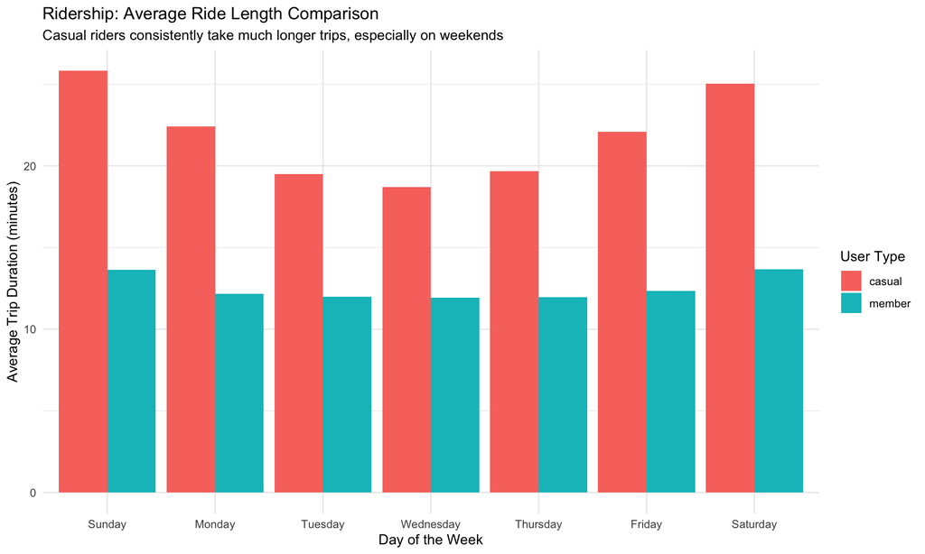

**Key Insight:** Casual riders take significantly longer trips on average compared to members. This behavior peaks on weekends (Saturday and Sunday), strongly indicating leisure or tourist activities rather than standard commuting.